# データ解析論II第9講

## 目次

## 前回の復習

## 構造方程式モデリングとは？

- 別名：共分散構造分析
- 重回帰分析・因子分析・パス解析などを合わせた手法．
- パス図などを使ってモデルを記述し，変数間の関係を明らかにする．
- 今までやってきた様々な手法を統合したもの．

## 変数の分類

- 観測変数か潜在変数か
  - 観測変数：実際に観察されている変数
    - 身長や体重，所得など．
    - 10点満点で尋ねているような主観的幸福度もここに含まれる．
  - 潜在変数：実際には観察し得ない変数
    - 文系能力・理系能力など
    - 何らかの概念を「構成」して推定する．
- 構造変数か誤差変数か
  - 構造変数：考察の対象となっている影響関係に，直接・間接的に影響を及ぼす変数
    - 観測変数や潜在変数はいずれも構造変数の1つ
  - 誤差変数：影響関係では説明できない変数．
- 外生変数か内生変数か
  - 外生変数：モデルの中で1度も他の変数の結果にならない変数
  - 内生変数：少なくとも一度は他の変数の結果になる変数

## 方程式の種類

- 測定方程式：構成概念が複数の観測変数に影響を与えている様子を記述する方程式
  - 構成概念が観測変数によってどのように測定されているかを示す

```
観測変数=係数1*構成概念1 + 係数2*構成概念2+....+誤差
```

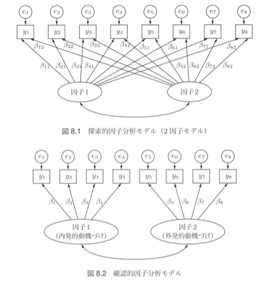

- 構造方程式：変数間の影響関係を表現するための式
  - 構成概念→構成概念：構成概念が他の構成概念の原因となる
  - 観測変数→観測変数：観測変数が他の観測変数の原因となる
    - 普通の回帰分析と一致
  - 観測変数→構成概念：観測変数が構成概念の原因となる

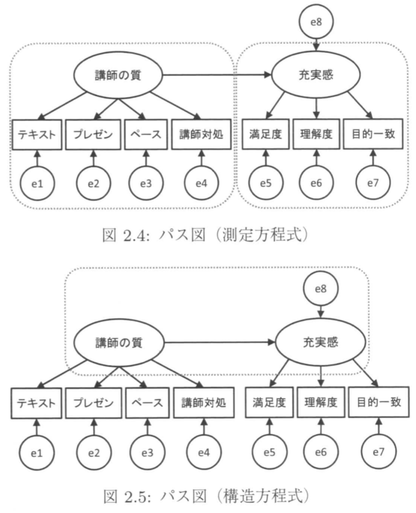

## 例題：

- セミナーにおける充実感と講師の質に関する関係性を分析する

**[こちらからどうぞ](https://www.dropbox.com/sh/zgf6y4w09m90k80/AABpAypwKTnR23GRErD7dMq9a?dl=0)**

```r
library(DT)
library(readr)
seminar <- read_csv("../data/seminar.csv")
DT::datatable(seminar)
```

|  | No | x1 | x2 | x3 | x4 | x5 | x6 | x7 |
| --- | --- | --- | --- | --- | --- | --- | --- | --- |
| 1 | 1 | 3 | 5 | 4 | 5 | 5 | 5 | 4 |
| 2 | 2 | 4 | 4 | 4 | 5 | 3 | 4 | 2 |
| 3 | 3 | 4 | 4 | 4 | 4 | 5 | 4 | 1 |
| 4 | 4 | 2 | 3 | 2 | 2 | 4 | 2 | 4 |
| 5 | 5 | 1 | 1 | 1 | 1 | 1 | 1 | 1 |
| 6 | 6 | 3 | 4 | 4 | 4 | 2 | 4 | 2 |
| 7 | 7 | 4 | 4 | 3 | 2 | 1 | 4 | 2 |
| 8 | 8 | 4 | 4 | 4 | 4 | 4 | 4 | 2 |
| 9 | 9 | 5 | 5 | 5 | 5 | 1 | 1 | 1 |
| 10 | 10 | 4 | 4 | 3 | 4 | 4 | 4 | 2 |

[output cut: 108 more lines]

## 分析の手続き

- 最初に探索的因子分析を行う
  - 講師の質：「テキスト」「プレゼン」「ペース」「講師対処」
  - 充実感：「満足度」「理解度」「目的一致」
- 講師の質によって「充実感」を説明できるのではないか？
- 使うパッケージ：

```r
library(lavaan)
```

```r
library(semPlot)
```

## 想定モデル

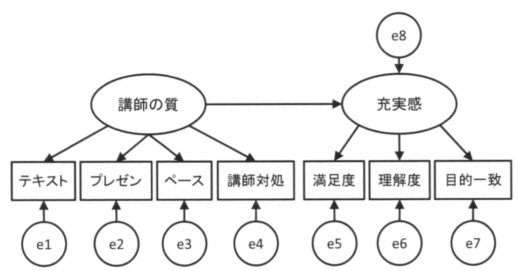

## モデル式

- 測定方程式：`=~`の左側には構成概念を，右側には観測変数を配置する．

```
f1 =~ x1+x2+x3+x4
f2 =~ x5+x6+x7
```

## モデル式

- 構造方程式：`~`の左には内生変数（応答変数）を，右側には外生変数（説明変数）を配置する．

```
f2 ~ f1
```

## モデル式

- 共変関係：それぞれの変数間に存在する相関関係も考慮できる．下記のように記述できるが，実際には自動的に考慮するようになっているが，誤差変数と外生的な構造変数には共変関係が仮定されないため，設定が必要．

```
x2 ~~ x4
```

- 以上をまとめてモデルオブジェクトに代入する

## モデル

- 作成

```r
model1<-'
f1 =~ x1+x2+x3+x4
f2 =~ x5+x6+x7
f2 ~ f1
'
```

- 計算

```r
fit1 <- sem(model1, seminar, "ML")
```

## 分析結果の出力

```r
summary(fit1)
```

```
## lavaan 0.6-7 ended normally after 47 iterations
##
##   Estimator                                       DWLS
##   Optimization method                           NLMINB
##   Number of free parameters                         22
##
##   Number of observations                           118
##
## Model Test User Model:
##                                               Standard      Robust
##   Test Statistic                                 6.740      12.068
##   Degrees of freedom                                13          13
##   P-value (Chi-square)                           0.915       0.522
##   Scaling correction factor                                  0.714
##   Shift parameter                                            2.622
##        simple second-order correction
##
## Parameter Estimates:
##
##   Standard errors                           Robust.sem
##   Information                                 Expected
##   Information saturated (h1) model        Unstructured
##
## Latent Variables:
##                    Estimate  Std.Err  z-value  P(>|z|)
##   f1 =~
##     x1                1.000
##     x2                1.993    0.861    2.316    0.021
##     x3                1.447    0.531    2.726    0.006
##     x4                1.529    0.588    2.601    0.009
##   f2 =~
##     x5                1.000
##     x6                0.663    0.276    2.403    0.016
##     x7                0.363    0.180    2.017    0.044
##
## Regressions:
##                    Estimate  Std.Err  z-value  P(>|z|)
##   f2 ~
##     f1                1.162    0.761    1.528    0.127
##
```

[output cut: 8 more lines]

```
##    .x7                1.627    0.085   19.157    0.000
##     f1                0.000
##    .f2                0.000
##
## Variances:
##                    Estimate  Std.Err  z-value  P(>|z|)
##    .x1                0.923    0.166    5.562    0.000
##    .x2                0.284    0.150    1.888    0.059
##    .x3                1.146    0.149    7.713    0.000
##    .x4                0.967    0.190    5.095    0.000
##    .x5                1.195    0.400    2.989    0.003
##    .x6                1.401    0.228    6.147    0.000
##    .x7                0.744    0.150    4.973    0.000
##     f1                0.136    0.107    1.274    0.203
##    .f2                0.632    0.484    1.305    0.192
```

## 構造方程式モデリングのメリット：

- 柔軟にモデル構築ができる
- しかし，データが少なすぎると十分な分析ができない．

## モデルの評価：

```r
summary(fit1, fit.measure=TRUE)
```

```
## lavaan 0.6-7 ended normally after 47 iterations
##
##   Estimator                                       DWLS
##   Optimization method                           NLMINB
##   Number of free parameters                         22
##
##   Number of observations                           118
##
## Model Test User Model:
##                                               Standard      Robust
##   Test Statistic                                 6.740      12.068
##   Degrees of freedom                                13          13
##   P-value (Chi-square)                           0.915       0.522
##   Scaling correction factor                                  0.714
##   Shift parameter                                            2.622
##        simple second-order correction
##
## Model Test Baseline Model:
##
##   Test statistic                                78.723      56.323
##   Degrees of freedom                                21          21
##   P-value                                        0.000       0.000
##   Scaling correction factor                                  1.634
##
## User Model versus Baseline Model:
##
##   Comparative Fit Index (CFI)                    1.000       1.000
##   Tucker-Lewis Index (TLI)                       1.175       1.043
##
##   Robust Comparative Fit Index (CFI)                            NA
##   Robust Tucker-Lewis Index (TLI)                               NA
##
## Root Mean Square Error of Approximation:
##
##   RMSEA                                          0.000       0.000
##   90 Percent confidence interval - lower         0.000       0.000
##   90 Percent confidence interval - upper         0.034       0.086
##   P-value RMSEA <= 0.05                          0.973       0.755
##
##   Robust RMSEA                                                  NA
```

[output cut: 38 more lines]

```
##    .x7                1.627    0.085   19.157    0.000
##     f1                0.000
##    .f2                0.000
##
## Variances:
##                    Estimate  Std.Err  z-value  P(>|z|)
##    .x1                0.923    0.166    5.562    0.000
##    .x2                0.284    0.150    1.888    0.059
##    .x3                1.146    0.149    7.713    0.000
##    .x4                0.967    0.190    5.095    0.000
##    .x5                1.195    0.400    2.989    0.003
##    .x6                1.401    0.228    6.147    0.000
##    .x7                0.744    0.150    4.973    0.000
##     f1                0.136    0.107    1.274    0.203
##    .f2                0.632    0.484    1.305    0.192
```

- \(\chi^2\) 値：帰無仮説が採択されるとよいが，データが多すぎると有意になりがち．

- これだけで評価してはいけない
- CFI(Comparative Fit Index，比較適合度指標)：0-1の間の数値を取る指標，1に近いほど当てはまりがよく，0.95以上あれば良いモデル．
- TLI(Tucker-Lewis Index)も1に近いほど当てはまりが良いが，1を超えることもある
- RMSEA：0.05以下であれば当てはまりがよく，0.1以上であれば当てはまりが悪い．
- SRMR(Standardized Root Mean Square Residual，標準化残差平方平均)：標本の分散，共分散とモデルにより再現される分散・共分散の差である残差によってモデル適合を検討する指標．0に近いほど当てはまっている．

## モデルの出力

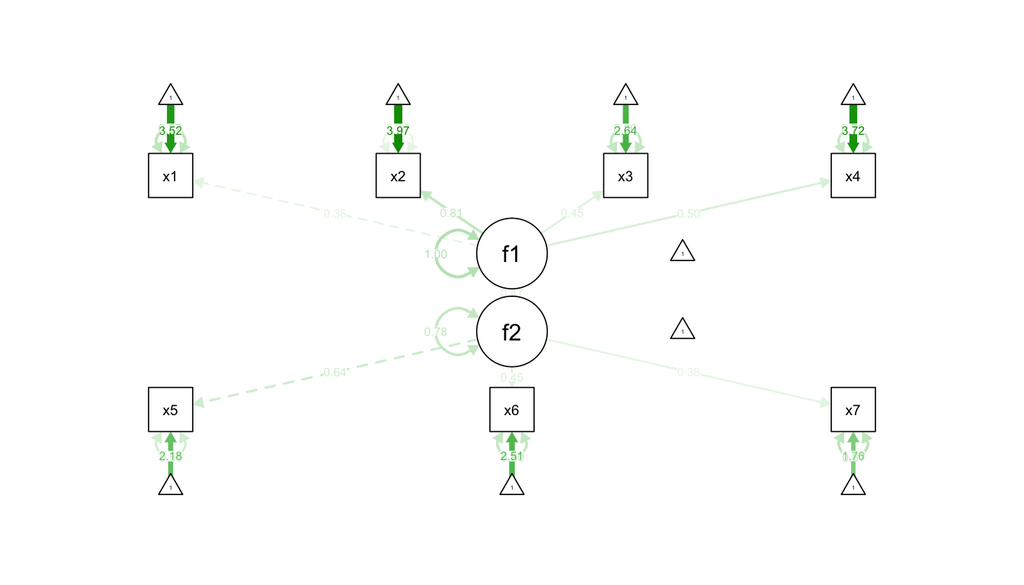

```r
semPaths(fit1, "std", title = FALSE)
```

## 分析結果の解釈

- 2種類の母数推定
  - 非標準化推定値：データを標準化せずに分析を行った際に得られる推定値，変数単位の影響を受ける．
  - 標準化推定値：データを標準化して分析を行った際に得られる推定値，すべての構造変数が標準化されているので，単位の影響を受けない．
    - 「構成概念」を扱うときには非標準化推定値の解釈が難しいために，標準化推定値を報告することが多い

## 非標準化推定値の算出(信頼区間も)

```r
parameterestimates(fit1)
```

```
##    lhs op rhs   est    se      z pvalue ci.lower ci.upper
## 1   f1 =~  x1 1.000 0.000     NA     NA    1.000    1.000
## 2   f1 =~  x2 1.993 0.861  2.316  0.021    0.306    3.679
## 3   f1 =~  x3 1.447 0.531  2.726  0.006    0.406    2.487
## 4   f1 =~  x4 1.529 0.588  2.601  0.009    0.377    2.681
## 5   f2 =~  x5 1.000 0.000     NA     NA    1.000    1.000
## 6   f2 =~  x6 0.663 0.276  2.403  0.016    0.122    1.203
## 7   f2 =~  x7 0.363 0.180  2.017  0.044    0.010    0.717
## 8   f2  ~  f1 1.162 0.761  1.528  0.127   -0.329    2.653
## 9   x1 ~~  x1 0.923 0.166  5.562  0.000    0.598    1.248
## 10  x2 ~~  x2 0.284 0.150  1.888  0.059   -0.011    0.579
## 11  x3 ~~  x3 1.146 0.149  7.713  0.000    0.854    1.437
## 12  x4 ~~  x4 0.967 0.190  5.095  0.000    0.595    1.339
## 13  x5 ~~  x5 1.195 0.400  2.989  0.003    0.411    1.978
## 14  x6 ~~  x6 1.401 0.228  6.147  0.000    0.954    1.848
## 15  x7 ~~  x7 0.744 0.150  4.973  0.000    0.451    1.037
## 16  f1 ~~  f1 0.136 0.107  1.274  0.203   -0.073    0.344
## 17  f2 ~~  f2 0.632 0.484  1.305  0.192   -0.317    1.580
## 18  x1 ~1     3.619 0.095 38.208  0.000    3.433    3.804
## 19  x2 ~1     3.602 0.084 43.129  0.000    3.438    3.765
## 20  x3 ~1     3.153 0.110 28.642  0.000    2.937    3.368
## 21  x4 ~1     4.220 0.104 40.452  0.000    4.016    4.425
## 22  x5 ~1     3.085 0.131 23.636  0.000    2.829    3.341
## 23  x6 ~1     3.322 0.122 27.212  0.000    3.083    3.561
## 24  x7 ~1     1.627 0.085 19.157  0.000    1.461    1.794
## 25  f1 ~1     0.000 0.000     NA     NA    0.000    0.000
## 26  f2 ~1     0.000 0.000     NA     NA    0.000    0.000
```

## 標準化推定値の算出

```r
standardizedsolution(fit1)
```

```
##    lhs op rhs est.std    se      z pvalue ci.lower ci.upper
## 1   f1 =~  x1   0.358 0.137  2.607  0.009    0.089    0.627
## 2   f1 =~  x2   0.809 0.117  6.888  0.000    0.579    1.039
## 3   f1 =~  x3   0.446 0.102  4.358  0.000    0.245    0.646
## 4   f1 =~  x4   0.497 0.102  4.872  0.000    0.297    0.697
## 5   f2 =~  x5   0.637 0.159  3.999  0.000    0.325    0.949
## 6   f2 =~  x6   0.451 0.132  3.418  0.001    0.192    0.710
## 7   f2 =~  x7   0.356 0.117  3.047  0.002    0.127    0.584
## 8   f2  ~  f1   0.474 0.273  1.739  0.082   -0.060    1.009
## 9   x1 ~~  x1   0.872 0.098  8.866  0.000    0.679    1.065
## 10  x2 ~~  x2   0.345 0.190  1.816  0.069   -0.027    0.718
## 11  x3 ~~  x3   0.801 0.091  8.790  0.000    0.623    0.980
## 12  x4 ~~  x4   0.753 0.101  7.427  0.000    0.554    0.952
## 13  x5 ~~  x5   0.595 0.203  2.932  0.003    0.197    0.992
## 14  x6 ~~  x6   0.797 0.119  6.693  0.000    0.563    1.030
## 15  x7 ~~  x7   0.874 0.083 10.527  0.000    0.711    1.036
## 16  f1 ~~  f1   1.000 0.000     NA     NA    1.000    1.000
## 17  f2 ~~  f2   0.775 0.259  2.997  0.003    0.268    1.282
## 18  x1 ~1       3.517 0.308 11.435  0.000    2.914    4.120
## 19  x2 ~1       3.970 0.304 13.047  0.000    3.374    4.567
## 20  x3 ~1       2.637 0.186 14.194  0.000    2.273    3.001
## 21  x4 ~1       3.724 0.416  8.951  0.000    2.909    4.539
## 22  x5 ~1       2.176 0.135 16.149  0.000    1.912    2.440
## 23  x6 ~1       2.505 0.168 14.944  0.000    2.176    2.834
## 24  x7 ~1       1.764 0.117 15.039  0.000    1.534    1.993
## 25  f1 ~1       0.000 0.000     NA     NA    0.000    0.000
## 26  f2 ~1       0.000 0.000     NA     NA    0.000    0.000
```

## その他の指標

- 構成概念スコア：研究仮説で過程した構成概念の尺度上で，各観測対象がどの程度その特性を持っているのか示した値

```r
predict(fit1)
```

```
##            f1     f2
##   [1,]  0.495  1.535
##   [2,]  0.209  0.281
##   [3,]  0.179  0.669
##   [4,] -0.366  0.215
##   [5,] -1.117 -1.788
##   [6,]  0.094 -0.080
##   [7,] -0.046 -0.456
##   [8,]  0.171  0.544
##   [9,]  0.466 -0.788
##  [10,]  0.125  0.515
##  [11,]  0.132  0.352
##  [12,]  0.425  0.124
##  [13,] -0.953  0.788
##  [14,] -0.529 -1.416
```

[output cut: 104 more lines]

- 散布図を見てみる

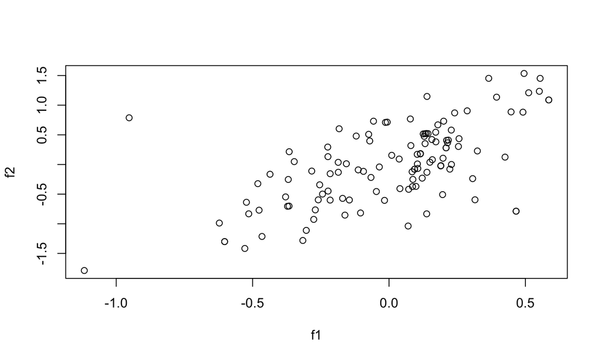

```r
factor_score<-predict(fit1)
plot(factor_score)
```

- 特異値（極値）の人に質問をしてみると，その他の要因の影響がわかるかも
  - 講師の質以外に充実感に影響を与える要因がわかるかも

## レポートでまとめる時に書くべきこと

- 構成概念に関する定義
- 観測変数の内容
- パス図
- 観測対象数，観測変数の数
- 推定方法
- ソフトウェア
- 標準化推定値
- 適合度(CFI，RMSEAなど)
- 母数の検定・標準誤差・信頼区間

## テキストマイニング

## テキストマイニングを行う

- テキストマイニング：文字列を対象とするデータ分析である．文章データを単語や文節で区切り，出現頻度や出現傾向などを解析することで有用な情報を取り出すテキストデータの分析方法のこと．
  - 小説的な文章の分析
  - twitterデータの分析

## テキストデータを読み込む

**[ファイル](https://www.dropbox.com/sh/hf6uf1ksn42iodo/AADOeNdXvqn_9nRsP_D7bZTca?dl=0)**

- 『吾輩は猫である（夏目漱石著）』[青空文庫](https://www.aozora.gr.jp/cards/000148/files/789_14547.html)にて公開されているものを一部使用
- テキストマイニングに必要な`RMeCab`パッケージのインストール

```
# Windowsの方
install.packages("RMeCab", repos = "https://rmecab.jp/R")

# Macの方
install.packages("RMeCab", repos ="https://rmecab.jp/R",
  type = "source")
```

## 最初に使うパッケージ

```r
library(RMeCab)
library(dplyr)
```

```r
library(readr)
library(ggplot2)
```

## テキストデータを読み込む

```r
RMecabFreq.result<-
  RMeCabFreq(file = "../data/wagahaiwa_nekodearu.txt")
```

```
## file = ../data/wagahaiwa_nekodearu.txt
## length = 1644
```

## データの表示

```r
# データを表示
head(RMecabFreq.result)
```

```
##       Term    Info1 Info2 Freq
## 1       あ フィラー     *    4
## 2     あー フィラー     *    1
## 3       え フィラー     *   11
## 4   なんか フィラー     *    1
## 5   あえて     副詞  一般    1
## 6 あたかも     副詞  一般    3
```

## データの表示

```r
# 頻度が多い順に並べ替える
RMecabFreq.result.2<-RMecabFreq.result %>%
  arrange(desc(Freq))
# データを表示
head(RMecabFreq.result.2)
```

```
##      Term  Info1    Info2 Freq
## 1626   。   記号     句点  329
## 234    の   助詞   連体化  295
## 193    て   助詞 接続助詞  288
## 168    は   助詞   係助詞  268
## 223    を   助詞   格助詞  247
## 147    た 助動詞        *  215
```

## データの表示

```r
# 全頻度の合計
sum(RMecabFreq.result.2$Freq)
```

```
## [1] 7447
```

## テキストの頻度と言葉の出現頻度

- 異語率：異語数（使用語彙の異なり率）を総語数（使用語彙の延べ数）で割ったもの
  - 異語率が高いほど語彙が豊かであることを示す．

```r
# データの個数/頻度の合計
length(RMecabFreq.result.2$Freq) /
  sum(RMecabFreq.result.2$Freq)
```

```
## [1] 0.22076
```

## テキストの頻度と言葉の出現頻度

- 語彙の出現頻度の出力

```r
write.table(RMecabFreq.result.2,
            file = "../data/wordlist.csv",
            sep = ",", row.names = T,
            col.names = NA,
            fileEncoding = "SHIFT_JIS")
```

## データのコロケーション

- コロケーション：2つ以上の単語の慣用的なつながりのこと．
- node で指定された語(ただし形態素原形)の前後に出てくる単語頻度を計算する

```r
collocate.result<-
  collocate(file = "../data/wagahaiwa_nekodearu.txt",
            node="吾輩", span=5)
```

```
## file = ../data/wagahaiwa_nekodearu.txt
## length = 1534
```

## データのコロケーション

```r
head(collocate.result)
```

```
##       Term Before After Span Total
## 1       、     10     1   11   123
## 2       。     53     4   57   329
## 3       「      2     2    4    42
## 4 あたかも      1     0    1     3
## 5     あと      1     0    1     4
## 6     ある     17     4   21    89
```

## 感情分析を行う

## twitterデータの感情分析

- それぞれのパッケージが必要となるので，インストールすること．

```r
# install.packages("rtweet")
library(rtweet)
# install.packages("devtools")
library(devtools)
```

```r
# install.packages("pipeR")
library(pipeR)
# install.packages("wordcloud2")
library(wordcloud2)
```

## ユーザーのタイムラインを取得

- キーワードで検索（第一引数：検索したいキーワード、第二引数:取得件数、第三引数:リツイートを取得するか、第四引数：どの言語のツイートを取得するか

```r
keyword <- search_tweets("明治大学",n=2000,
                         include_rts = FALSE,
                         langs = "ja")
```

- もしかしたらrtweetパッケージで初めて関数を使うときには認証が求められるかもしれません．
- その時は[コチラ](https://notchained.hatenablog.com/entry/2018/02/09/143304)にあわせて作業をしてください．

## タイムラインの出力

- 得られたデータを出力する．

```r
#作業のためにUTF-8で出力する．
write.csv(keyword$text,file = "../data/tweets.csv",
          sep = ",",col.names = T,row.names = F,
          fileEncoding = "UTF-8")
```

## タイムラインの出力

- 得られたデータを出力する．

```r
#結果を確認しやすいように（EXCELで開けるように）エンコードをSHIFT-JISにして出力する．
write.csv(keyword$text,file = "../data/tweets2.csv",
          sep = ",",col.names = T,row.names = F,
          fileEncoding = "SHIFT-JIS")
```

[output not shown]

[output cut: 904 more lines]

[output not shown]

## Stop Wordの設定

- 余計な言葉が入っていることもある．
  - ex. 「と思う」とか
- そんなのは“stopwords” というファイルを作って，除外処理をしよう
  - すでに代表的なストップワードは別途資料に入れてある．，．

**[除外すべき単語集](https://www.dropbox.com/sh/hf6uf1ksn42iodo/AADOeNdXvqn_9nRsP_D7bZTca?dl=0)**

## データの読み込みとStop Wordの設定

```r
stop_words <- read_csv("../data/stopwords.txt")
#頻出ワードを抽出
tweetword <- RMeCabFreq("../data/tweets.csv")
```

```
## file = ../data/tweets.csv
## length = 9338
```

```r
# stop_wordsに含まれる語句を除く
tweetword <- anti_join(tweetword, stop_words, by="Term")
```

## データの前処理

- 名詞だけを取り出します．
  - さらに名詞の中でも「一般」と「固有名詞」のみを取り出します．

```r
tweetword <-
  tweetword %>%
  filter(Info1 =="名詞") %>%
  filter(Info2== "一般"|Info2== "固有名詞")
```

## データの前処理

```r
tweetword <- tweetword %>%
  filter(Freq >=10 )
```

- 頻度が10以上のキーワードのみを抽出

```r
tweetword <-  tweetword %>%
  arrange(desc(Freq))
```

- Freq(頻度)の降順でソート

## ワードクラウドによる可視化

```r
tweetword %>%
  select("Term","Freq") %>%
  wordcloud2()
```

[interactive chart not shown]

## 感情分析：吾輩は猫である編

- 感情分析：テキストにおけるポジティブな単語やネガティブな単語を数えたり，「喜び」や「怒り」のような感情を表す単語を数える分析手法．
- [こちら](https://qiita.com/rmecab/items/b1a55a0e3a0a8637a461) も参考になりそう．

## 単語感情極性表(Semantic Orientations of Words)の読み込み

- [開発者サイト](http://www.lr.pi.titech.ac.jp/~takamura/pndic_ja.html)
- -1に近いほどネガティブ，+1に近いほどポジティブであると評価する．

```r
sow <-
  read.table("http://www.lr.pi.titech.ac.jp/~takamura/pubs/pn_ja.dic",
             sep=":",
             col.names=c("term","kana","pos","value"),
             colClasses=c("character","character",
                          "factor","numeric"),
             fileEncoding="Shift_JIS")
```

- 様々な辞書があるが，ここではこれを使いましょう．

## 単語感情極性表(Semantic Orientations of Words)の読み込み

- URLを途中で改行できないため，直接打ち込んでいる．

## 『吾輩は猫である』でやってみる．

```r
#頻出ワードを抽出
waganeko <- RMeCabFreq("../data/wagahaiwa_nekodearu.txt")
```

```
## file = ../data/wagahaiwa_nekodearu.txt
## length = 1644
```

```r
#単語感情極性表に含まれるものを抽出
waganeko2 <- waganeko %>%
  filter(Term %in% sow$term)
```

## 『吾輩は猫である』でやってみる．

```r
#単語感情極性表の属性を結合する
waganeko2 <- merge(waganeko2,sow,
                   by.x = c("Term","Info1"),
                   by.y = c("term","pos"))

#頻度(Freq) × 表の値(Value)でスコアを算出
waganeko2$Score <- waganeko2$Freq*waganeko2$value
```

## データの整理

```r
waganeko2 <-c(sum(waganeko2 > 0.5 & waganeko2 < 1.0),
               sum(waganeko2 > 0 & waganeko2 < 0.5),
               sum(waganeko2 < 0 & waganeko2 < -0.5),
               sum(waganeko2 < -0.5 & waganeko2 < -1)) %>%
  as.data.frame()
waganeko2$label <-c("Positive", "Neutral Plus",
                    "Neutral Minus", "Negative")
```

## 円グラフで出力

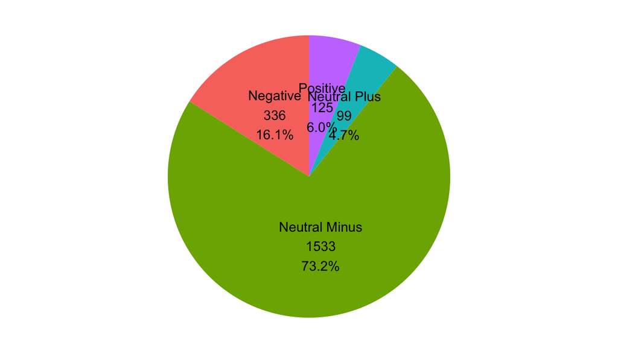

```r
waganeko2 %>%
    mutate(per = . / sum(.)) %>%
    mutate(label = paste0(label, "\n",
                          .,"\n",
                          scales::percent(per, 0.1))) %>%
    ggplot(aes(x = 0, y = ., fill = factor(label))) +
  geom_col() +
  coord_polar("y") +
  geom_text(aes(label = label),
            position = position_stack(vjust = 0.5)) +
  theme_void() +
  theme(legend.position = "none")
```

## 感情分析：tweet編

```r
#頻出ワードを抽出
tweetword <- RMeCabFreq("../data/tweets.csv")
```

```
## file = ../data/tweets.csv
## length = 9338
```

```r
#単語感情極性表に含まれるものを抽出
tweetword2 <- subset(tweetword,Term %in% sow$term)
```

## twitterデータでやってみる

```r
#単語感情極性表の属性を結合する
tweetword2 <- merge(tweetword2,sow,
                   by.x = c("Term","Info1"),
                   by.y = c("term","pos"))

#頻度(Freq) × 表の値(Value)でスコアを算出
tweetword2$Score <- tweetword2$Freq*tweetword2$value
```

## データの整理

```r
tweetword2 <-c(sum(tweetword2 > 0.5 & tweetword2 < 1.0),
               sum(tweetword2 > 0 & tweetword2 < 0.5),
               sum(tweetword2 < 0 & tweetword2 < -0.5),
               sum(tweetword2 < -0.5 & tweetword2 < -1)) %>%
  as.data.frame()
tweetword2$label <-c("Positive", "Neutral Plus",
                     "Neutral Minus", "Negative")
```

## 円グラフの出力

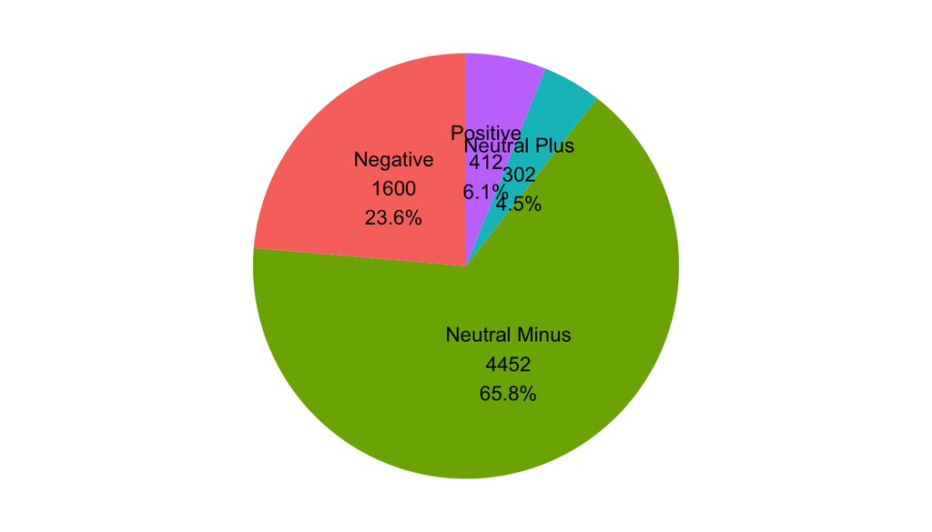

```r
tweetword2 %>%
    mutate(per = . / sum(.)) %>%
    mutate(label = paste0(label, "\n",
                          .,"\n",
                          scales::percent(per, 0.1))) %>%
    ggplot(aes(x = 0, y = ., fill = factor(label))) +
  geom_col() +
  coord_polar("y") +
  geom_text(aes(label = label),
            position = position_stack(vjust = 0.5)) +
  theme_void() +
  theme(legend.position = "none")
```

## 演習問題

- 特にありません．
- テキストマイニングはjamoviではできないので，RStudioのものだけを公開します．